# DAT 401

Charles Coonce

2024-08-30

# Statistical Modeling and Inference for Data Science

## Syllabus

### Course Learning Outcomes

At the completion of this course, students will be able to:

1. Explain the difference between type I and type II errors
2. Understand the notion of p-value; construct confidence intervals for means and proportions
3. Compute bootstrap confidence intervals
4. Use Bayes rule to calculate posterior probabilities
5. Compute bayesian credible intervals
6. Compute fitted curve in simple linear and polynomial regression
7. Understand bias-variance tradeoff
8. Perform subset selection method to fit a multiple linear regression model

### Course Materials

[Lecture Notes](https://math.la.asu.edu/~samara/StatMod-lectures)

Other useful literature:

1. [OpenIntro Statistics, edition, by D. Diez, M. Çetinkaya-Rundel & C. Barr](https://leanpub.com/openintro-statistics)
2. [An Introduction to Statistical Learning with Applications in R, by G. James, D. Witten, T. Hastie & R. Tibshirani](https://www.statlearning.com/)
3. A first course in Probability, 10th edition, by Sheldon Ross; publisher: Pearson, 2020

### Important Dates

| Assignment | Due Date (by 11:59pm AZ time) |
| --- | --- |
| HW1 | Sunday, 09/01/2024 |
| HW2 | Sunday, 09/08/2024 |
| HW3 | Saturday, 09/14/2024 |
| Exam 1 | Sunday, 09/15/2024 |
| HW4 | Sunday, 09/22/2024 |
| HW5 | Saturday, 09/28/2024 |
| Exam 2 | Sunday, 09/29/2024 |
| HW6 | Sunday, 10/6/2024 |
| HW7 | Friday, 10/11/2024 |
| Final Exam | Saturday, 10/12/2024 |

### Submitting Assignments

Lab assignments and projects should be submitted to the designated area in Canvas. You will work on homework assignments and submit them in [nbgrader](https://mathds.asu.edu/). Do not submit an assignment via email.

Assignment due dates follow Arizona Standard time. Click the following link to access the [Time Converter](http://www.thetimezoneconverter.com/) to ensure you account for the difference in Time Zones. Note: Arizona does not observe daylight savings time.

## Week 1

In this module we discuss basics of probability, the mathematical background of statistical modeling and inference.

#### Learning Objectives

1. Understand basic notions of probability theory: sample space, events, probability as a set function
2. Understand frequentist and bayesian interpretation of probability
3. Calculate probability of various events in finite sample space with equally likely outcomes
4. Understand the notion of conditional probability
5. Understand Total Probability Formula and Bayes’ Formula

#### Lecture Video Notes

**1. M1.1 - Probability**

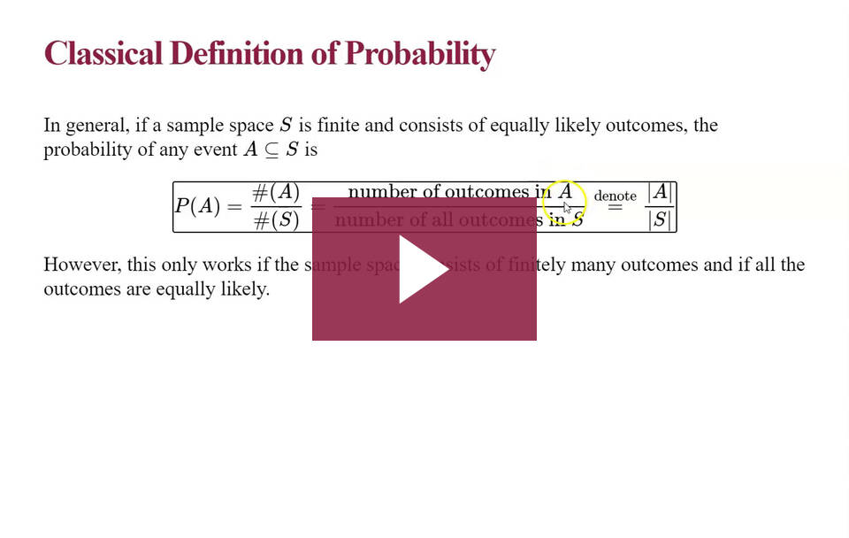

1. DS involves stochastic (random nature) models
2. Fundamental Notions:
   1. Outcomes of an experiment of interest
   2. Event (Collection of possible outcomes)
   3. Sample Space (collection of all possible outcomes)
   4. probability (quantifying the level of certainty about an event)
3. Classical Definition of Probability
   1. if a sample space **S** is finite and consists of equally likely outcomes
      1. the probability of any event **$A \subseteq S$** is **$P(A) = \frac{\text{Number of outcomes in } (A)}{\text{Number of all outcomes in } (S)}$**
      2. Also called **cardinality** of event A.
   2. Infinite Sets are different
      1. We use axioms and set operations.

**2. M1.2 - Review of Sets**

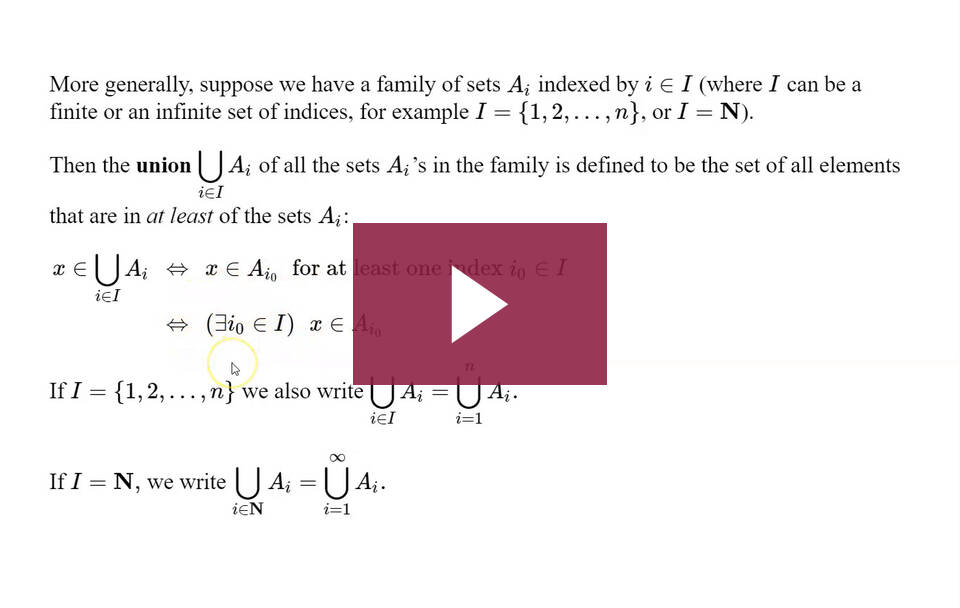

1. Complement: $A^C$
   1. $x \in A^C \iff x \notin A$ ( and $x \in S$ )
2. Union: $A \cup B$
   1. $x \in A \cup B \iff$ ( $x \in A$ **OR** $x \in B$ )
3. Intersection: $A \cap B$
   1. $x \in A \cap B \iff$ ( $x \in A$ **AND** $x \in B$ )
4. De Morgan’s Laws:
   1. $( A \cup B )^C = A^C \cap B^C$
   2. $( A \cap B)^C = A^C \cup B^C$

**3. M1.3 - Axioms of Probability**

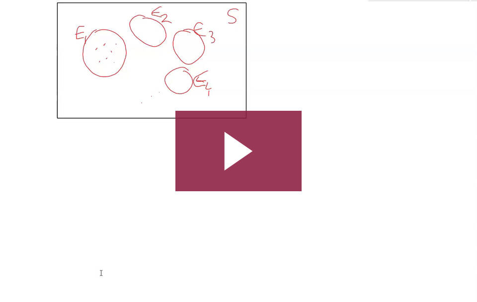

1. For any event E, $0 \leq P(E) \leq 1$
2. $P(S) = 1$
3. For any countable sequence of Mutually exclusive events $E_1$, $E_2$, ….
   1. in other words, $E_i \cap E_j = 0$ whenever $i \neq j$ , Then:

$$P\left(\bigcup_{i=1}^{\infty} E_i\right) = \sum_{i=1}^{\infty} P(E_i)$$

4. Notes:
   1. Adding a dot above the union set notation is meant to suggest the set is disjoint, suggesting we can apply axiom 3’s countable additivity.
      $$\dot{\bigcup}_{i=1}^{\infty} E_i$$
   2. The intersection $A \cap B$ of two events will be written shortly as $AB$. So, $P(AB)$ represents the probability that both events, $A$ and $B$ happen.
5. Properties of Probability
   1. $P(0) = 0$
   2. Let $A_1, A_2, \dots , A_n$ be disjoint sets. Then:
      $$P\left(\bigcup_{i=1}^{n} A_i\right) = \sum_{i=1}^{n} P(A_i)$$
   3. $P(A^c) = 1 - P(A)$
   4. $A \subseteq B \mapsto P(A) \leq P(B)$
   5. $P(A \cup B) = P(A) + P(B) - P(AB)$
      - **Note:** $P(A \cap\ B) = P(AB)$

**4. M1.4 - Interpreting Probability**

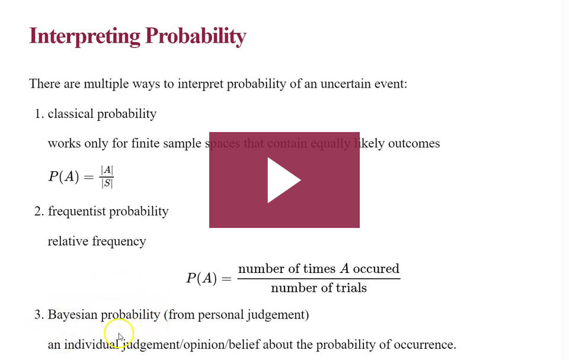

1. There are multiple ways to interpret probabilities:
   1. classical probability (only applies for finite sample spaces)
      $$P(A) = \frac{|A|}{|S|}$$
   2. frequentist probability (relative frequency)
      $$P(A) = \frac{\text{Number of times A occured}}{\text{Number of trials}}$$
   3. Bayesian probability (personal judgement)
      $$\text{An individual judgement / opinion / belief about the probability
      of occurrence}$$

**5. M1.5 - Examples**

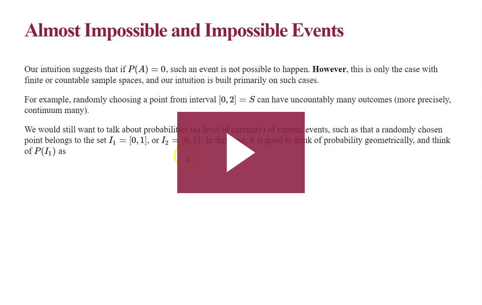

**5. M1.6 - Combinatorics**

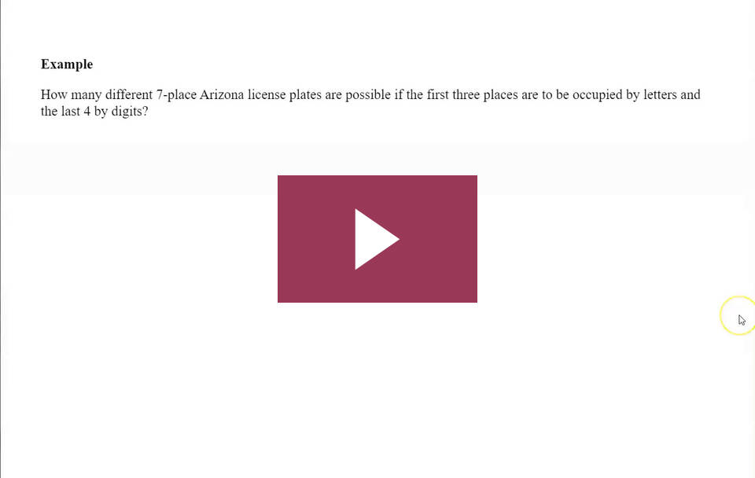

1. **The Basic Principle of Counting**
   1. You toss a coin and cast a die. How many possible outcomes can happen, where by an outcome we mean combination of face on the top of the coin and number on the top of the die?
      1. H - 1,2,3,4,5,6
      2. T - 1,2,3,4,5,6
      3. 2 possible coin outcomes, and 6 possible die outcomes - $2 * 6 = 12$ outcomes.
      4. Generalized to $n_1 * n_2 * ... n_i = total possible outcomes$
   2. How many ways can we put three people in line so that the order matters?
      1. permutation - $3 * 2 * 1 = 6$

**5. M1.7 - Combinations**

[figure not shown]

1. **Binomial Coefficient**
   1. $$\binom{n}{k} = \frac{n \cdot (n - 1) \cdot \ldots \cdot (n - k + 1)}{k!}
      = \frac{n!}{k! (n - k)!}$$
   2. **Example**
      1. There are 20 elks in a forest that is being observed by zoologists. Of these, 5 elks are tagged and then released. A certain time later 4 of the elks were randomly captured for analysis. What is the probability that exactly 2 of these elks caught are tagged? **Answer:**
      2. $$P(\text{exactly 2 are tagged}) = \frac{\binom{5}{2}
         \cdot \binom{15}{2}}{\binom{20}{4}} \approx 0.2167.$$

**5. M1.8 - Conditional Probability**

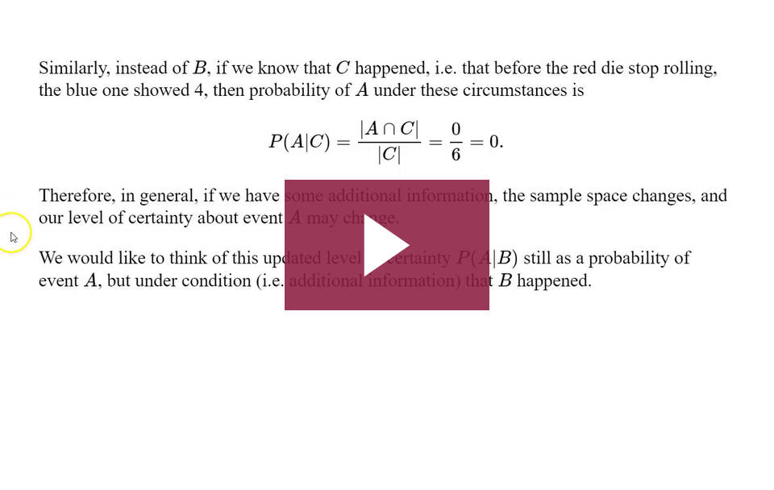

1. **Definition**
   1. Denoted $P(A|B)$ or probability of $A$ given $B$
   2. Another format:
      $$P(A|B) = \frac{|A \cap B|}{|B|} = \frac{|A \cap B|}{|B|} =
      \frac{2}{6} = \frac{1}{3}$$
      1. this works if $B$ is finite, but in general that is not the case. So…
   3. $$P(A|B) = \frac{|A \cap B|}{|B|} = \frac{\frac{|A \cap
      B|}{|S|}}{\frac{|B|}{|S|}} = \frac{P(A \cap B)}{P(B)}.$$
   4. $$P(A^c|B) = 1 - P(A|B)$$
   5. **Caution!**
      $$P(A|B^c) \neq 1 - P(A|B)$$
   6. **If $A \subseteq B$, then $AB = A$, and so:**
      $$P(A|B) = \frac{P(A)}{P(B)}$$

**5. M1.9 - Conditional Probability**

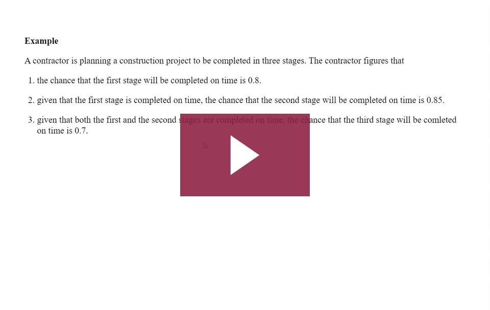

1. **Examples**
   1. Conditional probability $P(E_2|E_1)$ is often used when events $E_1$ and $E_2$ happen in chronological order, with $E_1$ appearing first.
      1. $$P(E_2 | E_1) = \frac{P(E_1 E_2)}{P(E_1)}.$$
   2. From $P(A|B) = \frac{P(AB)}{P(B)}$, we have
      $$P(AB) = P(B) \cdot P(A|B).$$
      1. Here, we used standard notation $AB$ to mean $A \cap B$. Because $AB = BA$, switching the roles of $A$ and $B$ in the previous formula, we also get
         $$P(AB) = P(A) \cdot P(B|A).$$
      2. Therefore,
         $$P(A) \cdot P(B|A) = P(AB) = P(B) \cdot P(A|B).$$
   3. Applying conditional probability to three sets, we get
      $$P(ABC) = P(CBA) = P(C|BA) P(BA) = P(C|AB) P(A) P(B|A)$$
      a. Thus,
      $$P(ABC) = P(A) P(B|A) P(C|AB)$$

**5. M1.10 - Total Probability Formula**

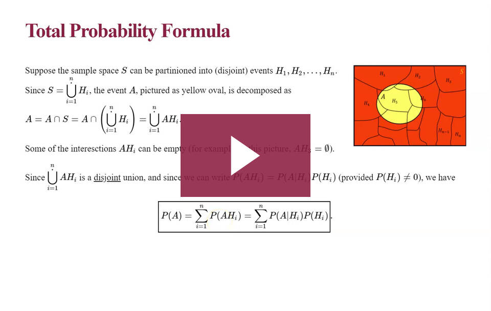

1. **Formula**
   1. Suppose the sample space $S$ can be partitioned into (disjoint) events $H_1, H_2, \ldots, H_n$.
      1. Since:
         $$S = \bigcup_{i=1}^{n} H_i,$$
      2. the event $A$ is decomposed as:
         $$A = A \cap S = A \cap \left( \bigcup_{i=1}^{n} H_i \right)
         = \bigcup_{i=1}^{n} A H_i.$$
         1. note: Some of the intersections $AH_i$ can be empty
      3. Since
         $$\bigcup_{i=1}^{n} AH_i$$
         is a disjoint union, and since we can write
         $$P(AH_i) = P(A|H_i)P(H_i)$$
         (provided $P(H_i) \neq 0$).
         1. We have:
            $$P(A) = \sum_{i=1}^{n} P(AH_i) = \sum_{i=1}^{n} P(A|H_i) P(H_i).$$

**5. M1.11 - Bayes Formula**

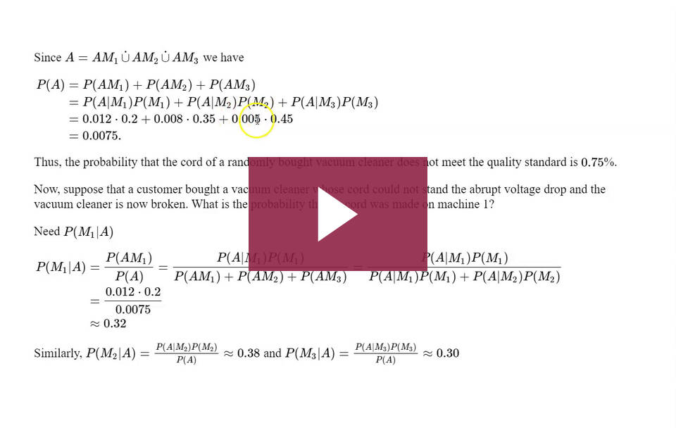

1. **Formula**
   1. It is important because it updates the probability (Level of certainty) in a particular event of interest, after gathering additional information.
   2. Suppose exactly one of the events $H_1, H_2, \ldots, H_n$ (called hypotheses) can happen. a.That is,
      $$S = H_1 \dot{\cup} H_2 \dot{\cup} \ldots \dot{\cup} H_n,$$
      b. with $P(H_i) \neq 0, \; i = 1, 2, \ldots, n.$ c.
      $$P(H_{i_0} \mid A) = \frac{P(A \mid
      H_{i_0}) P(H_{i_0})}{\sum\limits_{i=1}^{n}
      P(A \mid H_i) P(H_i)}$$
      d. another way to use Bayes formula:
      1. $$P(H_{i_0} \mid A) = \frac{P(A \mid H_{i_0}) P(H_{i_0})}{P(A)}
         = \frac{P(A \mid H_{i_0})
         P(H_{i_0})}{\sum\limits_{i=1}^{n} P(A \mid H_i) P(H_i)}.$$

**5. M1.12 - Bayes Formula**

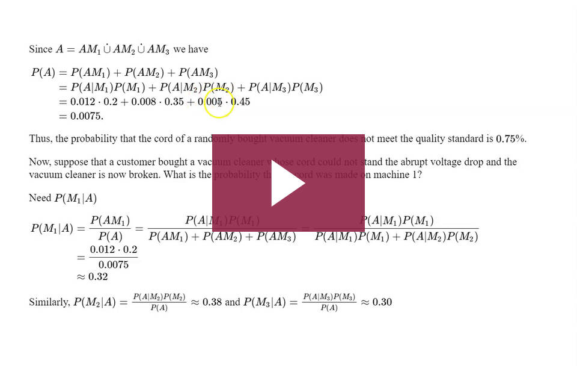

1. **Example**
   1. A blood test indicates the presence of a particular disease 96% of the time when the disease is actually present. The same test indicates the presence of the disease 1.2% of the time when the disease is not present. One percent of the population actually has the disease. If a person gets tested and the test turns positive (suggesting the disease), what is the probability that the person does have the disease?
      1. $D =$ randomly chosen person has the disease $( = H_{i_0} = H_1)$
      2. $T_+ =$ randomly chosen person gets positive on the test $( = A)$
      3. We need: $P(D|T_+) = ?$ $( = P(H_{i_0}| A ))$
      4. Given: $P(T_+ \mid D) = 0.96, \; P(T_+ \mid D^c) = 0.012,$ and that $P(D) = 0.01.$
      5. By the identity $P(A \mid B) P(B) = P(AB) = P(B \mid A) P(A)$, we have:
         1. $$P(D \mid T_+) P(T_+) = P(T_+ \mid D) P(D)$$
      6. and so
         1. $$P(D \mid T_+) = \frac{P(T_+ \mid D) P(D)}{P(T_+)}.$$
      7. We know $P(T_+ \mid D)$ and $P(D)$, but not $P(T_+)$. Nevertheless, we do know the probability of $T_+$ conditioned on each of the possible events $D$ and $D^c$, as well as their probabilities to happen $(P(D^c) = 1 - P(D) = 0.99 \; ( = P(H_2)))$. This means, we can find $P(T_+)$ by the total probability formula.
         1. $$P(T_+) = P(T_+ \mid D) P(D) + P(T_+ \mid D^c) P(D^c)$$
      8. Substituting in the formula, we get:
         1. $$P(D \mid T_+) = \frac{P(T_+ \mid D) P(D)}{P(T_+ \mid D) P(D)
            + P(T_+ \mid D^c) P(D^c)}$$
            $$= \frac{0.96 \cdot 0.01}{0.96 \cdot 0.01 + 0.012 \cdot 0.99}$$
            $$\approx 0.4469.$$

## Week 2

In this module we discuss independent events, random variables and distributions, histograms and densities, and expected value (mean).

#### Learning Objectives

1. Understand independent events, and their basic properties
2. Know the difference between discrete and continuous random variable; probability mass function (pmf) and probability density
3. Understand the difference between probability histogram (determined by pmf) and sample histogram
4. Recognize situations that give rise to binomial random variable
5. Recognize normal distribution
6. Understand kernel density estimate (KDE) algorithm as the way of estimating density from a collected sample
7. Understand the difference between population mean (expected value) and sample mean

#### Lecture Video Notes

**1. M2.1 - Independent Events**

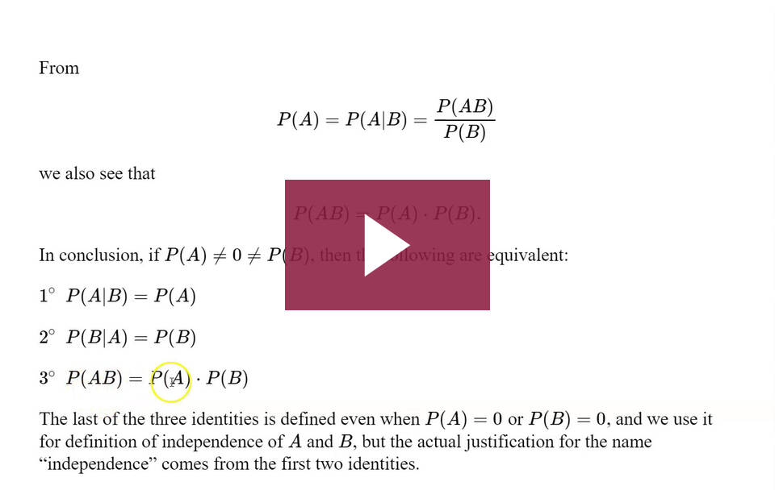

**1. M2.2 - Independence of Multiple Events**

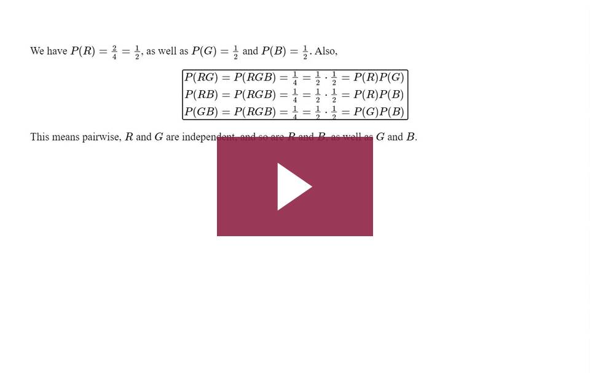

**1. M2.3 - Random Variables**

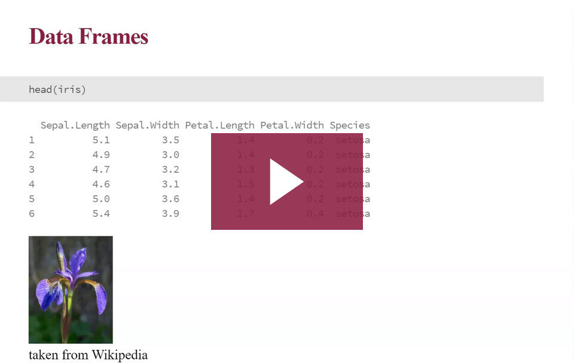

**1. M2.4 - Probability: Mass Function and Histogram**

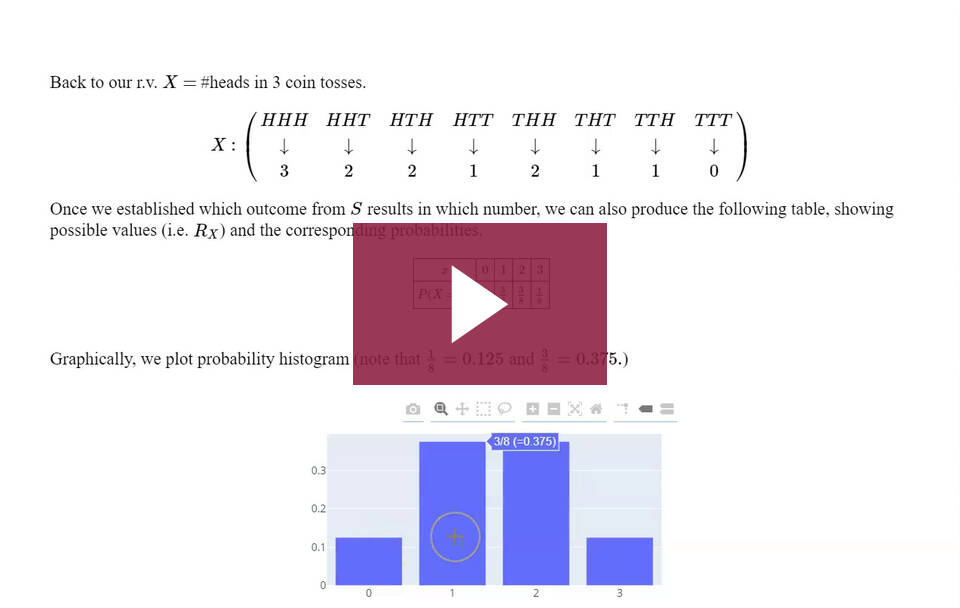

**1. M2.5 - Binomial RV**

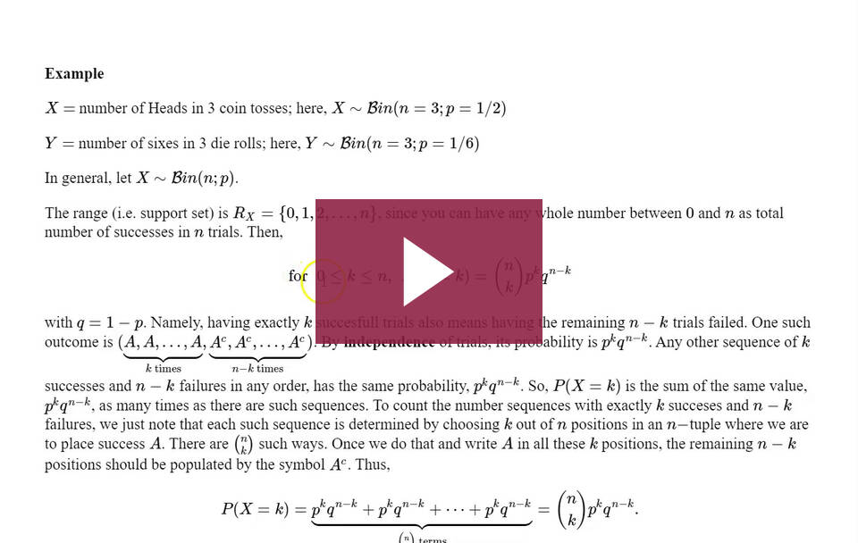

**1. M2.6 - Normal RV**

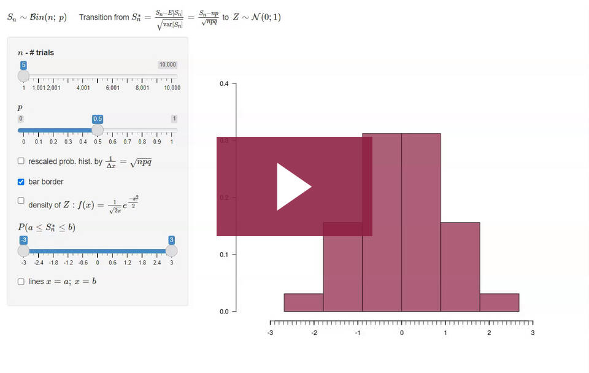

**1. M2.7 - Normal RV**

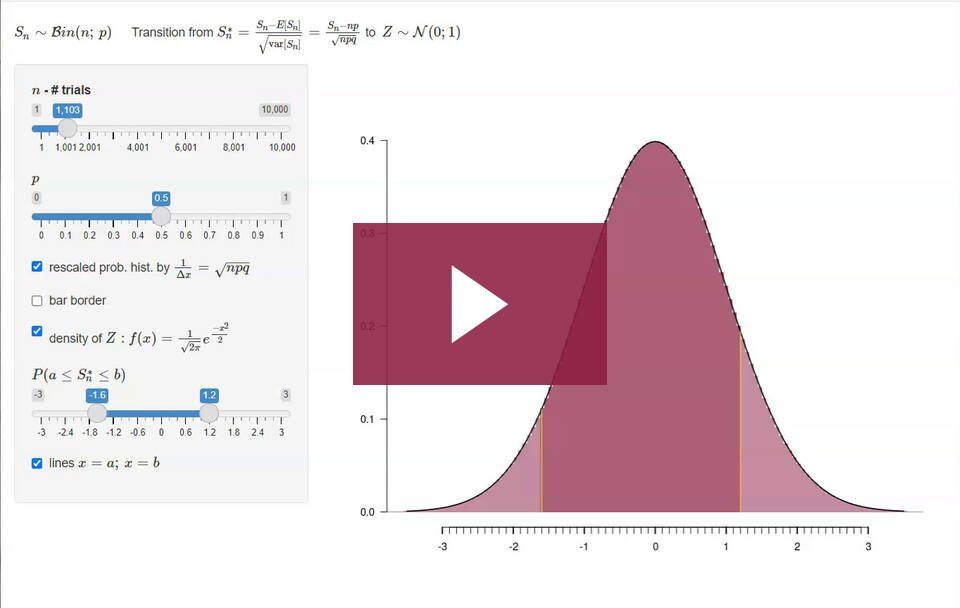

**1. M2.8 - Continuous RV**

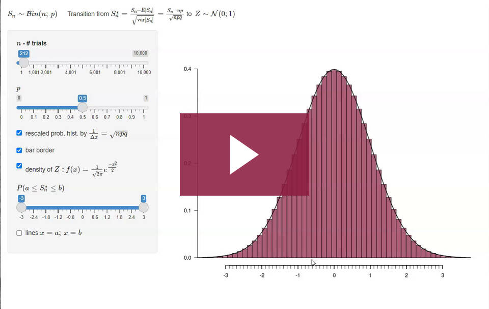

**1. M2.9 - Histograms**

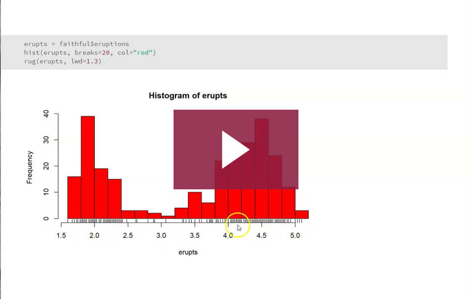

**1. M2.10 - Kernel Density Estimate (KDE) RV**

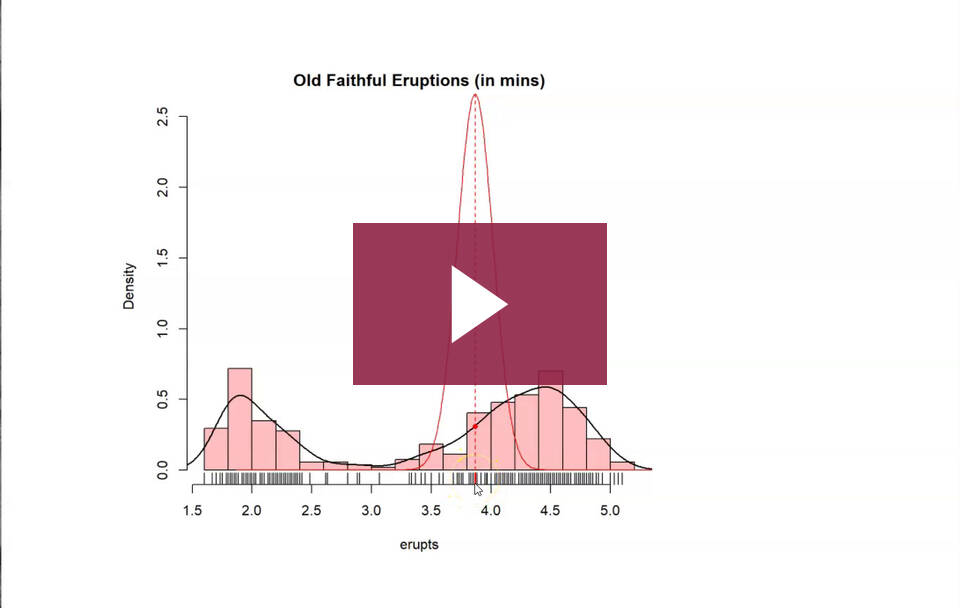

**1. M2.11 - KDE Example**

[figure not shown]

**1. M2.11 - Population Mean and Sample Mean**

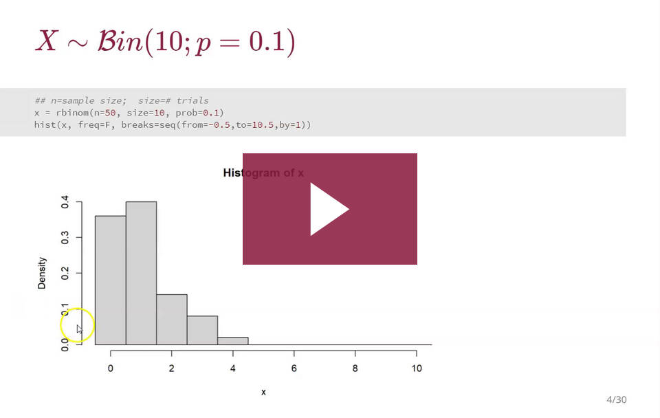